# Projekt 2 - wytyczne

Łukasz Wawrowski

Aktualizacja: 9 grudnia 2018

# Zadanie

Dla wybranych zmiennych z Polskiego Generalnego Sondażu Społecznego z 2010 roku wykonaj następujące zadania:

- wizualizacja dwóch zmiennych jakościowych,
- test niezależności $\chi^2$,
- wizalizacja zmiennej jakościowej i ilościowej,
- test t-średnich.

W zbiorze danych wartości zmiennych jakościowych są zastąpione przez ich kody. W dokumentacji badania dostęne są kwestionariusze, z których można odczytać oryginalne wartości cech.

# Przykład

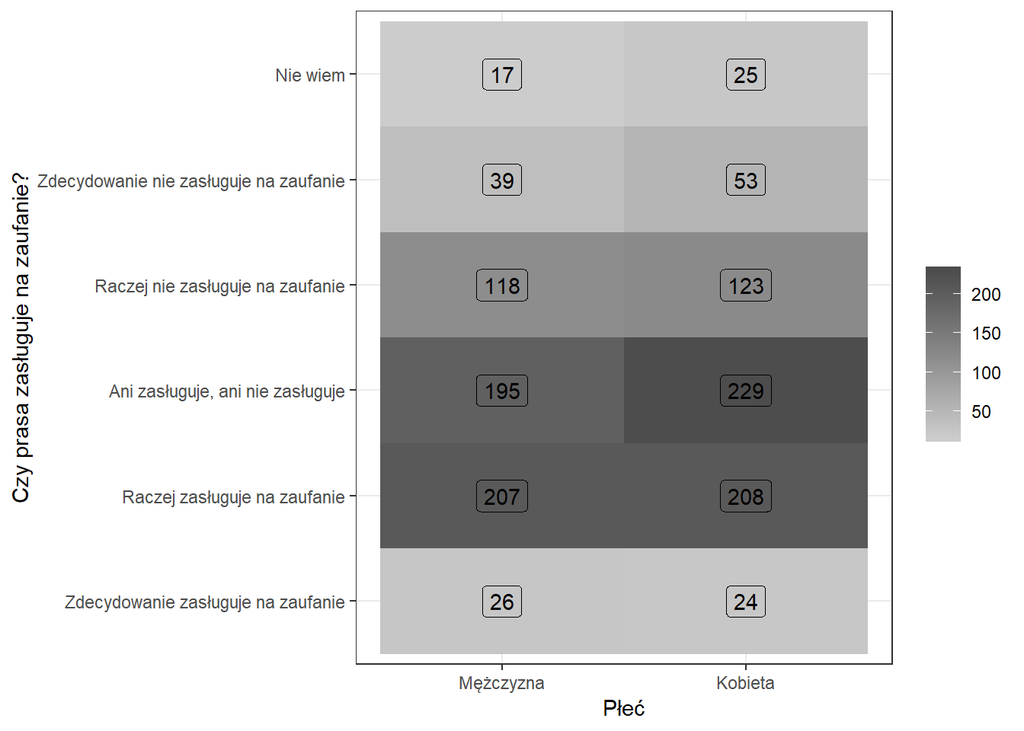

```r
library(tidyverse)
library(survey)

load("pgss.RData")

pgss <- pgss %>%
  mutate(one=1,
         q8=factor(q8, levels = c(1,2), labels = c("Mężczyzna", "Kobieta")),
         q61h=factor(q61h, levels = c(1,2,3,4,5,8), labels = c("Zdecydowanie zasługuje na zaufanie",
                                                               "Raczej zasługuje na zaufanie",
                                                               "Ani zasługuje, ani nie zasługuje",
                                                               "Raczej nie zasługuje na zaufanie",
                                                               "Zdecydowanie nie zasługuje na zaufanie",
                                                               "Nie wiem"),
                     ordered = T))

schemat <- svydesign(ids = ~recordid, weights = ~weight, data=pgss)

q8_q61h <- svyby(formula = ~one, by= ~q8 + q61h, design = schemat, FUN = svytotal)

ggplot(q8_q61h, aes(x=q8, y=q61h, fill=one)) +
  geom_tile() +
  geom_label(aes(label=round(one)), color="black") +
  scale_fill_gradient(low="grey80", high="grey30", name="") +
  xlab("Płeć") + ylab("Czy prasa zasługuje na zaufanie?") +
  theme_bw()
```

```r
svychisq(formula = ~q8 + q61h, design = schemat)
```

```
##
##  Pearson's X^2: Rao & Scott adjustment
##
## data:  svychisq(formula = ~q8 + q61h, design = schemat)
## F = 0.71417, ndf = 4.9914, ddf = 6299.2000, p-value = 0.6125
```

Nie ma podstaw do odrzucenia hipotezy zerowej - pomiędzy płcią a zaufaniem do pracy nie występuje zależność.

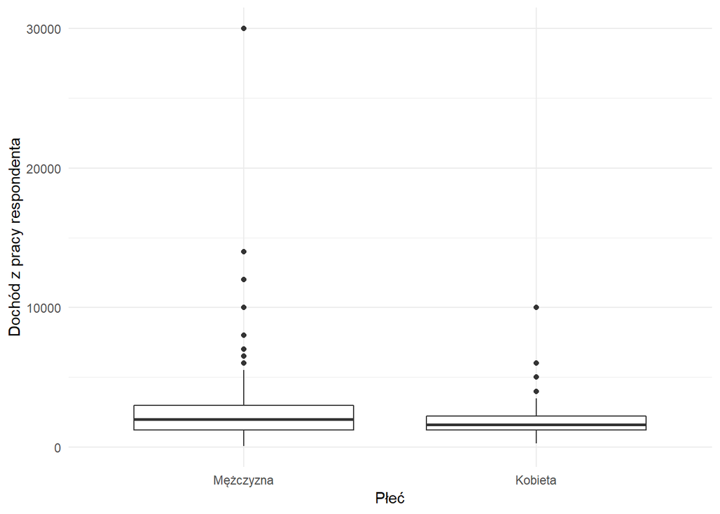

```r
ggplot(pgss, aes(x=q8, y=q32)) +
  geom_boxplot() +
  xlab("Płeć") + ylab("Dochód z pracy respondenta") +
  theme_minimal()
```

```r
svyttest(formula = q32 ~ q8, design = schemat)
```

```
##
##  Design-based t-test
##
## data:  q32 ~ q8
## t = -3.4381, df = 587, p-value = 0.0006273
## alternative hypothesis: true difference in mean is not equal to 0
## 95 percent confidence interval:
##  -864.5854 -236.7449
## sample estimates:
## difference in mean
##          -550.6651
```

Są podstawy do odrzucenia hipotezy zerowej - średnie dochody różnią się w grupach płci.

# Prezentacja

Podczas zajęć w dniu 21.01.2019 r. zadania projektowe mają być przedstawione w krótkiej prezentacji (około 5 slajdów) zawierającej wszystkie elementy wskazane w zadaniu.

Prezentacja w formacie .pdf oraz skrypt R muszą być wgrane na moodle do dnia 20.01.2019 r., godz. 23:00.

# Kryteria oceny

- wizualizacja - 3 punkty
- test $\chi^2$ - 2 punkty
- test t-średnich - 2 punkty
- dodatkowy test $\chi^2$ na innych zmiennych - 1 punkt
- dodatkowy test t-średnich na innych zmiennych - 1 punkt
- przeprowadzenie testu proporcji - 1 punkt
- przeprowadzenie testu rang - 1 punkt
- wizualizacja wykraczająca poza materiał omawiany podczas zajęć - 1 punkt
- najlepsza praca w grupie wybrana przez prowadzącego - 1 punkt
- oddanie pracy po terminie - -3 punkty